# Indel Signature InsDel_E

# InsDel_E

(corresponds to 83-type signature ID_E)

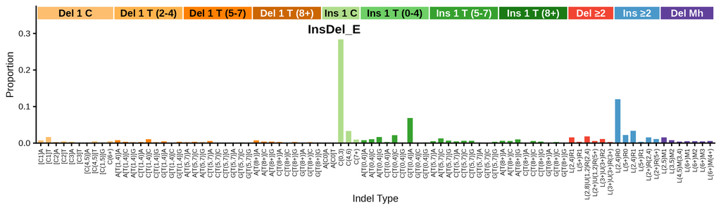

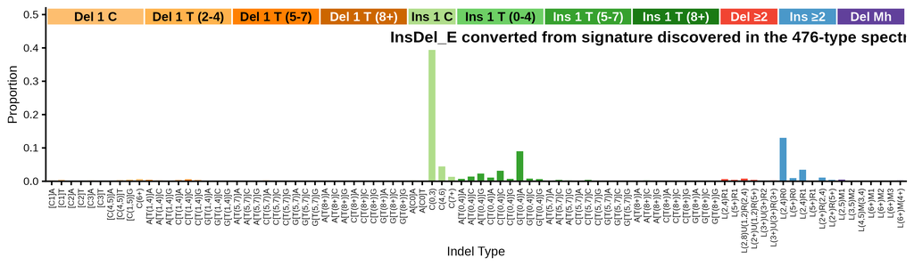

89-type spectrum of the linking tumor DRUP01340014T | cosine similarity to InsDel_E: 0.9776

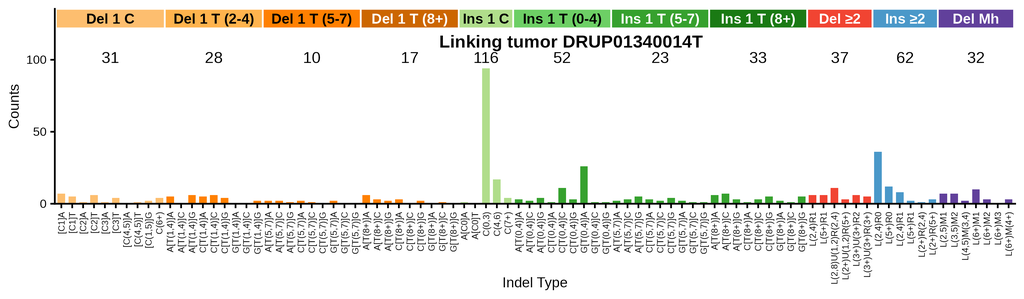

**Click to view decomposition of the linking tumor spectrum**

Partial mutation signature of DRUP01340014T due to InsDel_E

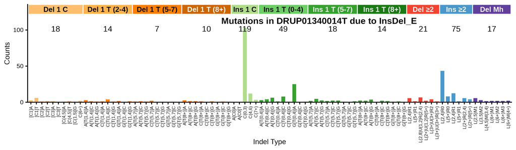

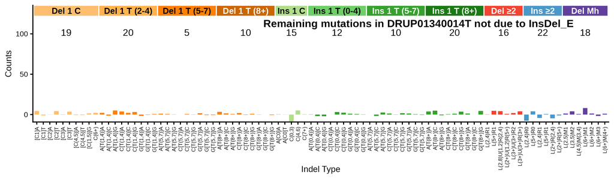

Max neg fraction (maximum allowed negative residual count as fraction of total): 0.10  
N subtract (mutation count assigned to signature): 362.2  
N residual (mutation count in residual “partial spectrum”): 78.8  
Total negative (sum of negative residual mutation counts): 43.9  
N negative channels (number of channels with negative residual): 28  
P(≥ total negative) (Monte Carlo estimated probability that negative-binomial-sampled spectra from the signature contributing N subtract mutations would produce a total negative count >= the observed Total negative; higher number means not surprising): 0.702

**Per-channel residual breakdown**

| Channel | Spectrum | Sig_Count | Residual | Sig_Prop |
| --- | --- | --- | --- | --- |
| [Del(C):R1]A | 7 | 2.6 | 4.4 | 0.00717 |
| [Del(C):R1]T | 5 | 6.0 | -1 | 0.01665 |
| [Del(C):R2]A | 1 | 1.1 | -0.1 | 0.00310 |
| [Del(C):R2]T | 6 | 1.7 | 4.3 | 0.00477 |
| [Del(C):R3]A | 1 | 1.4 | -0.4 | 0.00376 |
| [Del(C):R3]T | 4 | 0.3 | 3.7 | 0.00093 |
| [Del(C):R(4,5)]A | 0 | 0.6 | -0.6 | 0.00175 |
| [Del(C):R(4,5)]T | 1 | 1.6 | -0.6 | 0.00448 |
| [Del(C):R(1,5)]G | 2 | 0.6 | 1.4 | 0.00168 |
| Del(C):R(6,9) | 4 | 1.8 | 2.2 | 0.00509 |
| A[Del(T):R(1,4)]A | 5 | 2.9 | 2.1 | 0.00810 |
| A[Del(T):R(1,4)]C | 0 | 1.3 | -1.3 | 0.00363 |
| A[Del(T):R(1,4)]G | 6 | 0.9 | 5.1 | 0.00242 |
| C[Del(T):R(1,4)]A | 5 | 1.2 | 3.8 | 0.00322 |
| C[Del(T):R(1,4)]C | 6 | 3.8 | 2.2 | 0.01052 |
| C[Del(T):R(1,4)]G | 4 | 0.9 | 3.1 | 0.00240 |
| G[Del(T):R(1,4)]A | 0 | 1.7 | -1.7 | 0.00465 |
| G[Del(T):R(1,4)]C | 0 | 0.4 | -0.4 | 0.00118 |
| G[Del(T):R(1,4)]G | 2 | 1.4 | 0.6 | 0.00379 |
| A[Del(T):R(5,7)]A | 2 | 0.9 | 1.1 | 0.00254 |
| A[Del(T):R(5,7)]C | 2 | 1.4 | 0.6 | 0.00378 |
| A[Del(T):R(5,7)]G | 1 | 0.9 | 0.1 | 0.00244 |
| C[Del(T):R(5,7)]A | 2 | 2.0 | 0 | 0.00548 |
| C[Del(T):R(5,7)]C | 1 | 0.5 | 0.5 | 0.00124 |
| C[Del(T):R(5,7)]G | 0 | 0.2 | -0.2 | 0.00065 |
| G[Del(T):R(5,7)]A | 2 | 0.3 | 1.7 | 0.00091 |
| G[Del(T):R(5,7)]C | 0 | 0.6 | -0.6 | 0.00167 |
| G[Del(T):R(5,7)]G | 0 | 0.6 | -0.6 | 0.00152 |
| A[Del(T):R(8,)]A | 6 | 2.6 | 3.4 | 0.00722 |
| A[Del(T):R(8,)]C | 3 | 1.5 | 1.5 | 0.00412 |

[output cut: 59 more lines]

## 476-type representations corresponding to InsDel_E

Extracted 476-type signature corresponding to InsDel_E

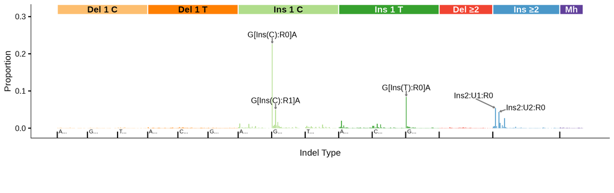

476-type spectrum of the linking tumor DRUP01340014T; cosine similarity to the extracted 476-type signature is 0.9371

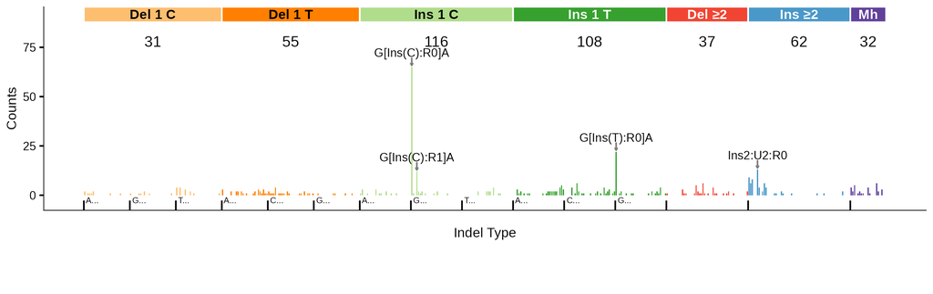

## 83-type signature corresponding to InsDel_E (ID_E)

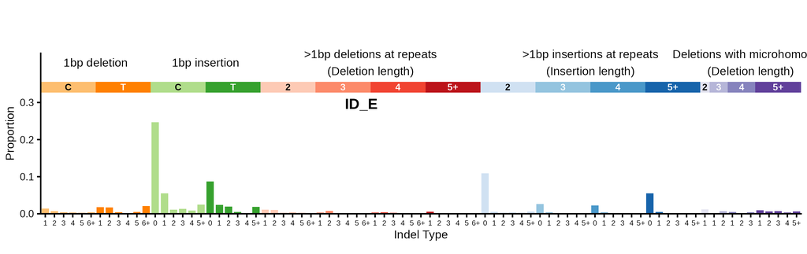

83-type signature converted from signature discovered in the 476-type spectra (using bipartite matching optimization) | cosine similarity to ID_E: 0.9749

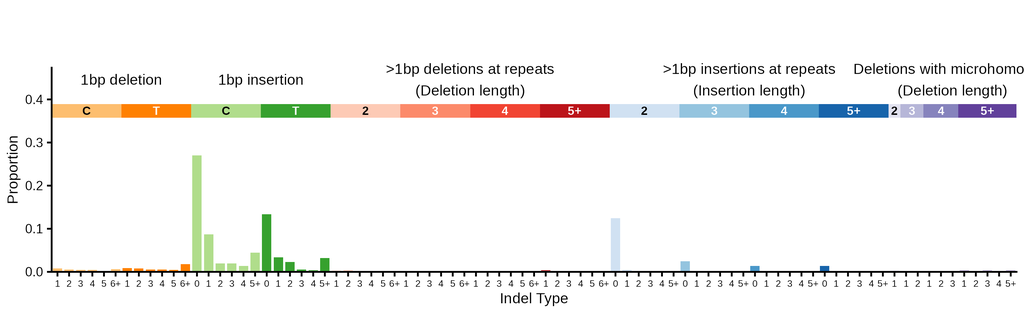

**Click to see flow diagrams: 476-type to 83-type collapse**

These Sankey diagrams show how the 476-type mutation categories are redistributed to 83-type categories using bipartite matching. We only show the diagrams for insertions or deletions of > 1 base because it is for these indels that 476-type categories map to > 1 83-type category.

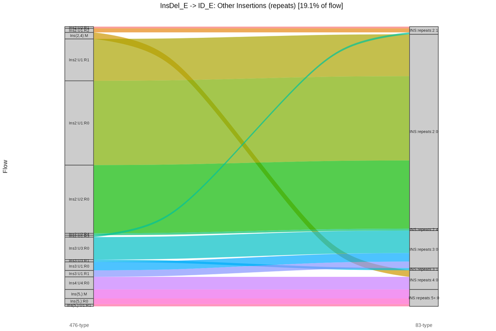

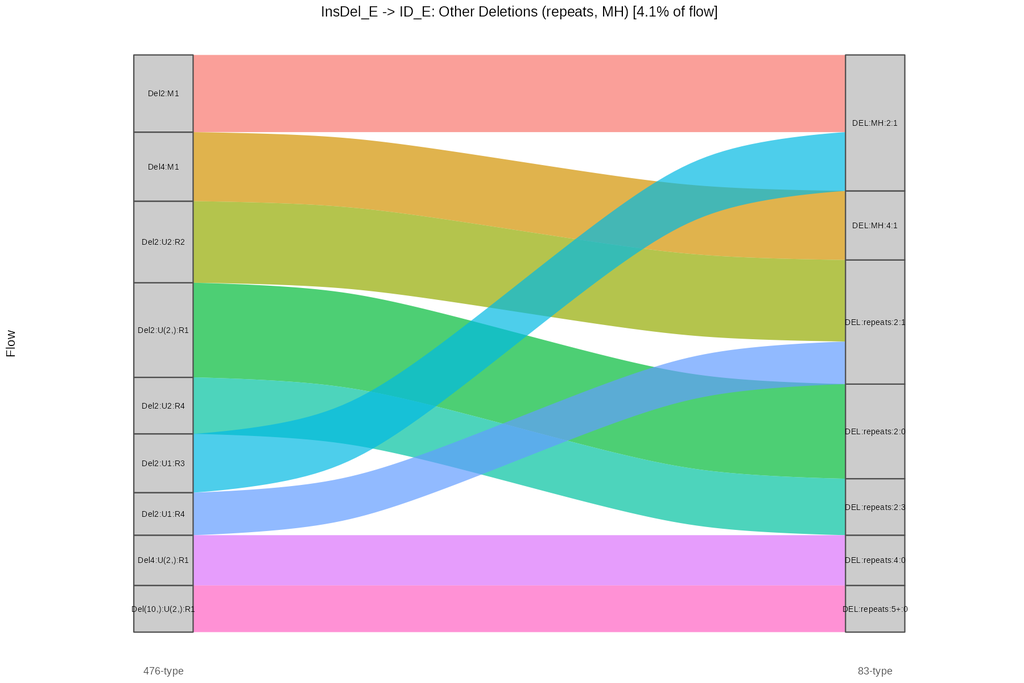

83-type spectrum of the linking tumor DRUP01340014T | cosine similarity to ID_E: 0.8429

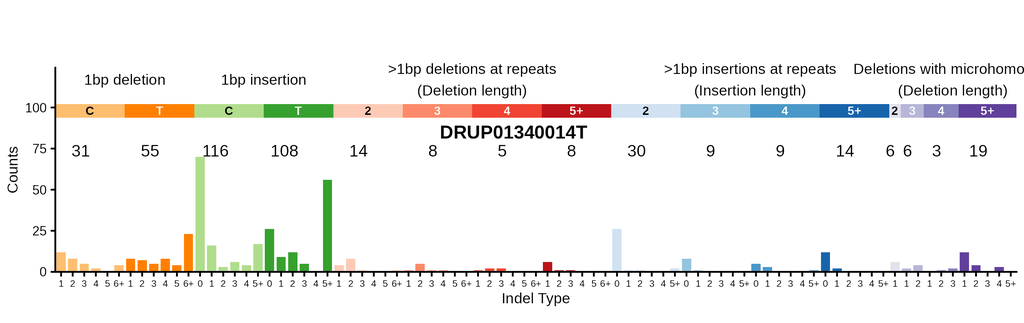

83-type spectrum of best 83-type matching tumor DRUP01340015T | cosine similarity to ID_E: 0.8988

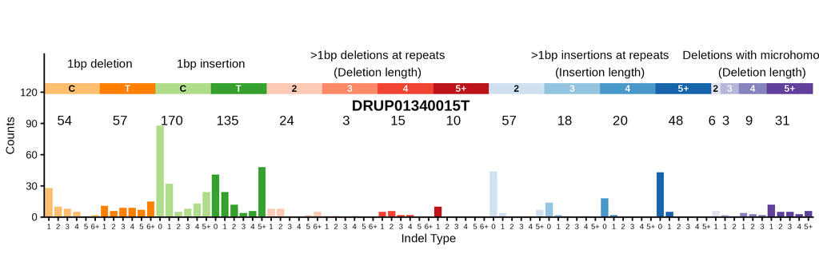